# Car Prices

## Background

[figure not shown]

This analysis compares two sedans from American car manufacture Chevrolet: the Cavalier and the Malibu. Is the price of a sedan affected by the mileage and model type?

The data was filtered to contain only Cavilier and Malibu sedans (no coupes or hatchbacks). There are 30 Cavaliers and 30 Malibus.

## The Model

The multiple linear regression model was applied to the data set. to obtain two regression lines, one for each vehicle.

$$\underbrace{Y_i}_{\text{Price}} = \overbrace{\beta_0 + \beta_1 \underbrace{X_{i1}}_{\text{Mileage}}}^{\text{Cavalier Line}} + \overbrace{\beta_2 \underbrace{X_{i2}}_{\text{Malibu}} + \beta_3 \underbrace{X_{i1} X_{i2}}_{\text{Interaction}}}^{\text{Adjustments to Line for Malibu}} + \epsilon_i$$

$\beta_0$ is the base intercept for the Cavalier’s regression line, and $\beta_1$ is the base slope coefficient. $\beta_2$ times the Malibu value is the adjustment needed for the Cavalier line’s y-intecept, and $\beta_3$ is the difference in slopes for the two cars. $X_{i2} = 0$ is used when the sedan is a Cavalier while $X_{i2} = 1$ when the sedan is a Malibu. Below are the models when simplified according to their $X_{i2}$ value which were used to create regression lines for each model.

| Vehicle | Value of $X_{i2}$ | Resulting Model |
| --- | --- | --- |
| Cavalier | $X_{i2} = 0$ | $Y_i = \beta_0 + \beta_1 X_{i1} + \epsilon_i$ |
| Malibu | $X_{i2} = 1$ | $Y_i = (\beta_0 + \beta_2) + (\beta_1 + \beta_3) X_{i1} + \epsilon_i$ |

We will test $\beta_2$ and $\beta_3$ to see whether they are are different from zero. This will tell us whether the two models have different y-intercepts (intial price)Since and whether they have different slopes (rate of depreciation).

### Test for Equal y-Intercepts

In the combined regression model, if $\beta_2 = 0$, then the regression lines have the same y-intercept. If $\beta_2$ is not equal to zero the y-intercepts are different. These hypotheses will be judged at the $\alpha=0.05$ significance level.

$$H_0: \beta_2 = 0 \quad \text{(Sedans have the same y-intercept)} \\
H_a: \beta_2 \neq 0 \quad \text{(Sedans have a different y-intercept)}\\
\alpha=0.05$$

### Test for Equal Slopes

If $\beta_3$ is zero, then the slopes of the two lines are the same. In other words, the relationship between price and mileage is the same for the two sedans. If $\beta_3$ is not zero, the relationship between price and mileage is different for the two models.

$$H_0: \beta_3 = 0 \quad \text{(Sedans have the same relationship between price and mileage)} \\
H_a: \beta_3 \neq 0 \quad \text{(Sedans have a different price-mileage relationship)}\\
\alpha=0.05$$

## Analysis

The following table shows the summary of the multiple linear regression for the relationship between price and mileage by sedan type:

```r
## Code for the linear regression
sedans.lm <- lm(Price ~ Mileage + Model + Mileage:Model, data=SedanPrices)
pander(summary(sedans.lm, caption="Multiple Linear Regression Summary the Relationship Between Price and Mileage by Sedan Type "))
```

|  | Estimate | Std. Error | t value | Pr(>\|t\|) |
| --- | --- | --- | --- | --- |
| **(Intercept)** | 15244 | 266.8 | 57.14 | 2.418e-51 |
| **Mileage** | -0.1111 | 0.01192 | -9.32 | 5.51e-13 |
| **ModelMalibu** | 3897 | 396 | 9.839 | 8.214e-14 |
| **Mileage:ModelMalibu** | -0.005688 | 0.01818 | -0.3129 | 0.7555 |

Fitting linear model: Price ~ Mileage + Model + Mileage:Model

| Observations | Residual Std. Error | $R^2$ | Adjusted $R^2$ |
| --- | --- | --- | --- |
| 60 | 580.4 | 0.9362 | 0.9327 |

The summary of the multiple linear regression shows that the interaction of mileage and model is insignificant. So the model was simplified by removing the $\beta_3$ term. The new summary is below:

```r
sedansSim.lm <- lm(Price ~ Mileage + Model, data=SedanPrices)
pander(summary(sedansSim.lm, caption="Simplified Linear Regression Summary the Relationship Between Price and Mileage by Sedan Type"))
```

|  | Estimate | Std. Error | t value | Pr(>\|t\|) |
| --- | --- | --- | --- | --- |
| **(Intercept)** | 15294 | 211.3 | 72.37 | 8.647e-58 |
| **Mileage** | -0.1136 | 0.008928 | -12.72 | 2.72e-18 |
| **ModelMalibu** | 3782 | 148.8 | 25.42 | 8.711e-33 |

Fitting linear model: Price ~ Mileage + Model

| Observations | Residual Std. Error | $R^2$ | Adjusted $R^2$ |
| --- | --- | --- | --- |
| 60 | 575.7 | 0.936 | 0.9338 |

The scatterplot below shows the regression lines for the Cavalier and the Malibu. The lines are parallel because there is no change in slope.

[figure not shown]

```r
palette(c("#0040ff", "#00ff00"))
plot(Price ~ Mileage, data=SedanPrices, col=Model, main="Relationship Between Price and Mileage", pch=16, ylab="Price in U.S. Dollars")
abline(a= sedansSim.lm$coefficients[1], b=sedansSim.lm$coefficients[2], col=palette()[2])
abline(a=sedansSim.lm$coefficients[1]+sedansSim.lm$coefficients[3], b=sedansSim.lm$coefficients[2], col=palette()[1])
legend("topright", col=palette(), pch=16, legend=c("Chevy Malibu", "Chevy Corolla"), bty="n", text.col = palette())
```

## Assumptions

Below are plots to check the assumptions of the test. In the residual versus fitted plot, there does not seem to be a pattern so we can assume the linear relation assumption is satisfied. The variance does looks slightly unconstant but not enough to invalidate the results. The error terms in the QQ plot appear normal (within the dotted blue lines), and the residual versus order plot does not show a dramatic pattern, indicating the error terms are independent. No assumptions are violated.

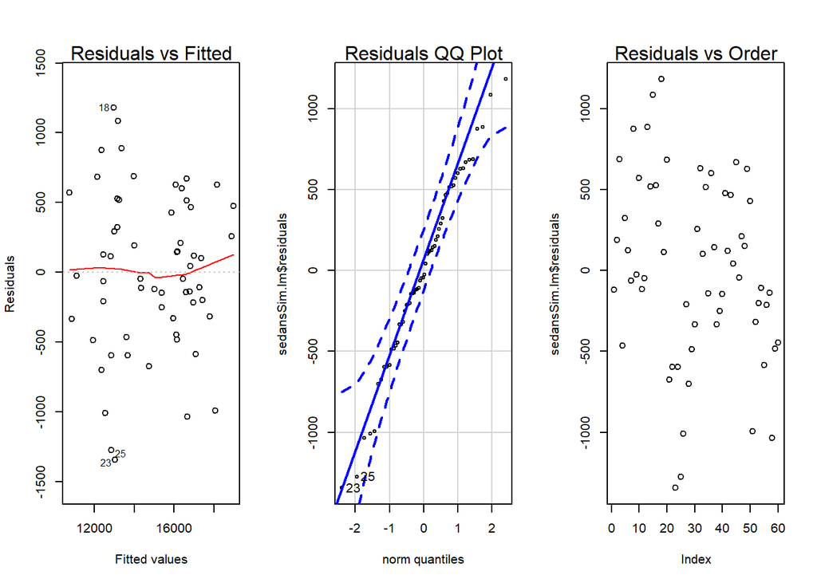

```r
# The code from the Civic v Corolla assumption plots was used to add titles
par(mfrow=c(1,3))
plot(sedansSim.lm, which=1, caption=NA)
mtext(side=3, text="Residuals vs Fitted")
qqPlot(sedansSim.lm$residuals)
mtext(side=3,text="Residuals QQ Plot")
plot(sedansSim.lm$residuals)
mtext(side=3, text="Residuals vs Order")
```